# pgPEN_DeKegel_overlap

Phoebe Parrish

10/21/2021

## Setup

### Assign variables

```r
date <- Sys.Date()

## work laptop
base_dir <- file.path("/Users", "pparrish", "Google_Drive", "01_Research", "01_Projects", "01_Paralog_pgRNA",
                      "01_Data", "Paralog_SL_meta_analysis")

## personal laptop
# base_dir <- file.path("/Users", "phoebeparrish", "Google_Drive", "01_Research", "01_Projects", "01_Paralog_pgRNA",
#                       "01_Data", "Paralog_SL_meta_analysis")

in_dir <- file.path(base_dir, "01_input_files")

out_dir <- file.path(base_dir, "02_output_files")
```

### Import files

```r
d.DeKegel <- read_csv(file.path(in_dir, "DeKegel_Table_S8.csv"))
d.Parrish <- read_rds(file.path(in_dir, "d.PC9_v_HeLa_paralog_target_GI_wide_flag"))

d.Dede <- read_tsv(file.path(in_dir, "Dede_Table_S2.txt"))
d.druggable <- read_tsv(file.path(in_dir, "finan_druggability_with_ensembl_id.txt"))
d.Broad_drug_info <- read_csv(file.path(in_dir, "primary-screen-replicate-collapsed-treatment-info.csv"))
```

## Analysis

### Get Ensembl IDs and merge

```r
d.DeKegel <- d.DeKegel %>%
  unite(ensembl_pair, c(A1_ensembl, A2_ensembl), sep = "_", remove = FALSE)

d.Parrish <- d.Parrish %>%
  rename(ensembl_pair_1 = ensembl_paralog_pair) %>%
  unite(ensembl_pair_2, c(target2_ensembl_id, target1_ensembl_id), sep = "_", remove = FALSE)
```

```r
# d.Dede %>%
#   separate(gene_pair, c("gene1", "gene2"), sep = "_") %>%
```

```r
d.Parrish_DeKegel_1 <- inner_join(d.Parrish, d.DeKegel, by = c("ensembl_pair_1" = "ensembl_pair"))
d.Parrish_DeKegel_1
```

```
## # A tibble: 241 × 94
##    paralog_pair      PC9_double_GI_s… PC9_gene_gene_G… PC9_GI_fdr HeLa_double_GI_…
##    <chr>                        <int>            <dbl>      <dbl>            <int>
##  1 CLEC4C|CLEC6A                 1027            0.749   0.000489              751
##  2 SLC25A28|SLC25A37               23           -0.944   0.000489               49
##  3 CREBBP|EP300                    19           -0.973   0.00132                48
##  4 PMPCB|UQCRC1                  1030            0.931   0.00142              1028
##  5 ZNF143|ZNF76                    51           -0.727   0.00155               186
##  6 AP2A1|AP2A2                     18           -0.978   0.00328                24
##  7 AP1B1|AP2B1                     41           -0.809   0.00430               124
##  8 OXSR1|STK39                     13           -1.03    0.00430                69
##  9 ARL8A|ARL8B                     65           -0.644   0.00433               253
## 10 BTBD10|KCTD20                 1017            0.586   0.00477               244
## # … with 231 more rows, and 89 more variables: HeLa_gene_gene_GI_score <dbl>,
## #   HeLa_GI_fdr <dbl>, target1 <chr>, target2 <chr>, ensembl_pair_1 <chr>,
## #   ensembl_pair_2 <chr>, target1_ensembl_id <chr>, target1_hgnc_symbol <chr>,
## #   target1_chr <chr>, target1_start_pos <dbl>, target2_ensembl_id <chr>,
## #   target2_hgnc_symbol <chr>, target2_chr <chr>, target2_start_pos <dbl>,
## #   PC9_target1_TPM <dbl>, PC9_target2_TPM <dbl>, PC9_target1_entrez_id <int>,
## #   PC9_target2_entrez_id <int>, PC9_target1_essential <lgl>, …
```

```r
d.Parrish_DeKegel_2 <- inner_join(d.Parrish, d.DeKegel, by = c("ensembl_pair_2" = "ensembl_pair"))
d.Parrish_DeKegel_2
```

```
## # A tibble: 786 × 94
##    paralog_pair   PC9_double_GI_sc… PC9_gene_gene_G… PC9_GI_fdr HeLa_double_GI_…
##    <chr>                      <int>            <dbl>      <dbl>            <int>
##  1 CCNL2|CCNL1                    1           -2.31    0.000165               10
##  2 CDK6|CDK4                      2           -1.54    0.000340              210
##  3 CSTF2T|CSTF2                  32           -0.890   0.000441               17
##  4 CRKL|CRK                     116           -0.464   0.00107               119
##  5 TIAL1|TIA1                    20           -0.970   0.00154                18
##  6 GSK3B|GSK3A                    3           -1.43    0.00162                 4
##  7 HNRNPD|HNRNPAB                11           -1.04    0.00171                36
##  8 BRD3|BRD2                     40           -0.816   0.00214                97
##  9 COQ10B|COQ10A                  7           -1.12    0.00224                66
## 10 SEC24B|SEC24A                  6           -1.12    0.00246                54
## # … with 776 more rows, and 89 more variables: HeLa_gene_gene_GI_score <dbl>,
## #   HeLa_GI_fdr <dbl>, target1 <chr>, target2 <chr>, ensembl_pair_1 <chr>,
## #   ensembl_pair_2 <chr>, target1_ensembl_id <chr>, target1_hgnc_symbol <chr>,
## #   target1_chr <chr>, target1_start_pos <dbl>, target2_ensembl_id <chr>,
## #   target2_hgnc_symbol <chr>, target2_chr <chr>, target2_start_pos <dbl>,
## #   PC9_target1_TPM <dbl>, PC9_target2_TPM <dbl>, PC9_target1_entrez_id <int>,
## #   PC9_target2_entrez_id <int>, PC9_target1_essential <lgl>, …
```

```r
d.Parrish_DeKegel <- bind_rows(d.Parrish_DeKegel_1, d.Parrish_DeKegel_2)
d.Parrish_DeKegel
```

```
## # A tibble: 1,027 × 94
##    paralog_pair      PC9_double_GI_s… PC9_gene_gene_G… PC9_GI_fdr HeLa_double_GI_…
##    <chr>                        <int>            <dbl>      <dbl>            <int>
##  1 CLEC4C|CLEC6A                 1027            0.749   0.000489              751
##  2 SLC25A28|SLC25A37               23           -0.944   0.000489               49
##  3 CREBBP|EP300                    19           -0.973   0.00132                48
##  4 PMPCB|UQCRC1                  1030            0.931   0.00142              1028
##  5 ZNF143|ZNF76                    51           -0.727   0.00155               186
##  6 AP2A1|AP2A2                     18           -0.978   0.00328                24
##  7 AP1B1|AP2B1                     41           -0.809   0.00430               124
##  8 OXSR1|STK39                     13           -1.03    0.00430                69
##  9 ARL8A|ARL8B                     65           -0.644   0.00433               253
## 10 BTBD10|KCTD20                 1017            0.586   0.00477               244
## # … with 1,017 more rows, and 89 more variables: HeLa_gene_gene_GI_score <dbl>,
## #   HeLa_GI_fdr <dbl>, target1 <chr>, target2 <chr>, ensembl_pair_1 <chr>,
## #   ensembl_pair_2 <chr>, target1_ensembl_id <chr>, target1_hgnc_symbol <chr>,
## #   target1_chr <chr>, target1_start_pos <dbl>, target2_ensembl_id <chr>,
## #   target2_hgnc_symbol <chr>, target2_chr <chr>, target2_start_pos <dbl>,
## #   PC9_target1_TPM <dbl>, PC9_target2_TPM <dbl>, PC9_target1_entrez_id <int>,
## #   PC9_target2_entrez_id <int>, PC9_target1_essential <lgl>, …
```

### Parrish vs. De Kegel

```r
d.Parrish_DeKegel
```

```
## # A tibble: 1,027 × 94
##    paralog_pair      PC9_double_GI_s… PC9_gene_gene_G… PC9_GI_fdr HeLa_double_GI_…
##    <chr>                        <int>            <dbl>      <dbl>            <int>
##  1 CLEC4C|CLEC6A                 1027            0.749   0.000489              751
##  2 SLC25A28|SLC25A37               23           -0.944   0.000489               49
##  3 CREBBP|EP300                    19           -0.973   0.00132                48
##  4 PMPCB|UQCRC1                  1030            0.931   0.00142              1028
##  5 ZNF143|ZNF76                    51           -0.727   0.00155               186
##  6 AP2A1|AP2A2                     18           -0.978   0.00328                24
##  7 AP1B1|AP2B1                     41           -0.809   0.00430               124
##  8 OXSR1|STK39                     13           -1.03    0.00430                69
##  9 ARL8A|ARL8B                     65           -0.644   0.00433               253
## 10 BTBD10|KCTD20                 1017            0.586   0.00477               244
## # … with 1,017 more rows, and 89 more variables: HeLa_gene_gene_GI_score <dbl>,
## #   HeLa_GI_fdr <dbl>, target1 <chr>, target2 <chr>, ensembl_pair_1 <chr>,
## #   ensembl_pair_2 <chr>, target1_ensembl_id <chr>, target1_hgnc_symbol <chr>,
## #   target1_chr <chr>, target1_start_pos <dbl>, target2_ensembl_id <chr>,
## #   target2_hgnc_symbol <chr>, target2_chr <chr>, target2_start_pos <dbl>,
## #   PC9_target1_TPM <dbl>, PC9_target2_TPM <dbl>, PC9_target1_entrez_id <int>,
## #   PC9_target2_entrez_id <int>, PC9_target1_essential <lgl>, …
```

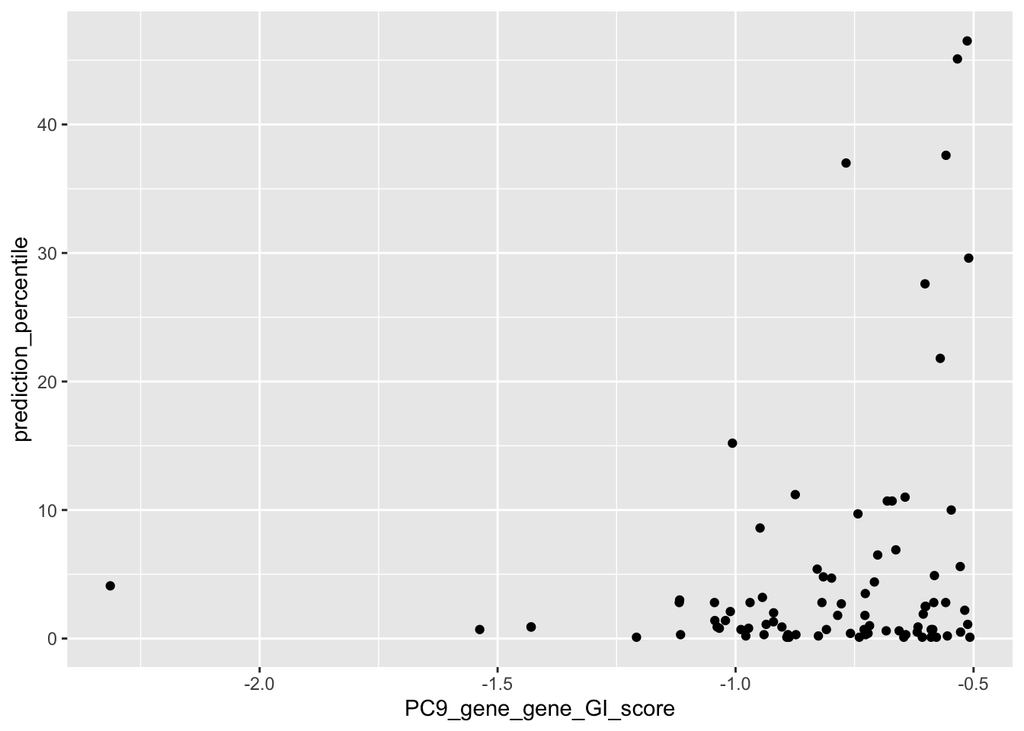

```r
d.Parrish_DeKegel %>%
  filter(PC9_SL_flag == "SL_in_PC9") %>%
  ggplot(aes(x = PC9_gene_gene_GI_score, y = prediction_percentile)) +
  geom_point()
```

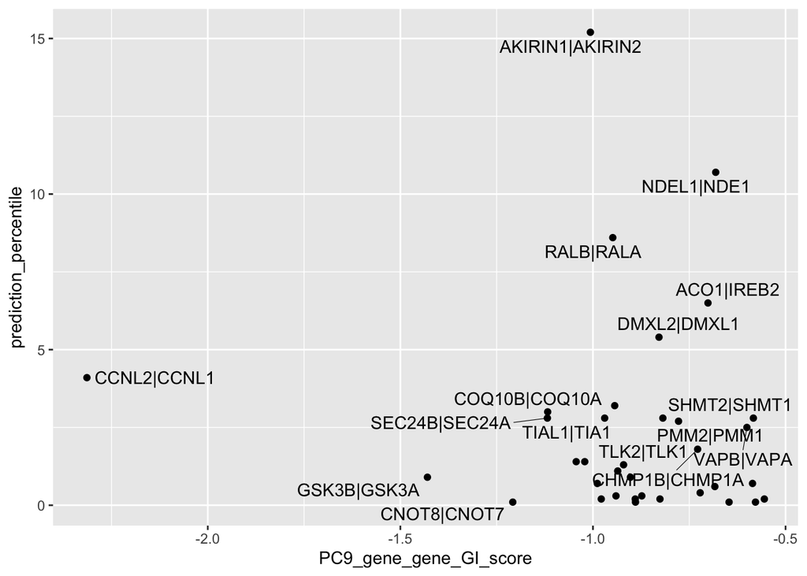

```r
d.Parrish_DeKegel %>%
  filter(broad_SL_flag == "SL_in_both") %>%
  ggplot(aes(x = PC9_gene_gene_GI_score, y = prediction_percentile)) +
  geom_point() +
  geom_text_repel(aes(label = paralog_pair), segment.size = 0.2)
```

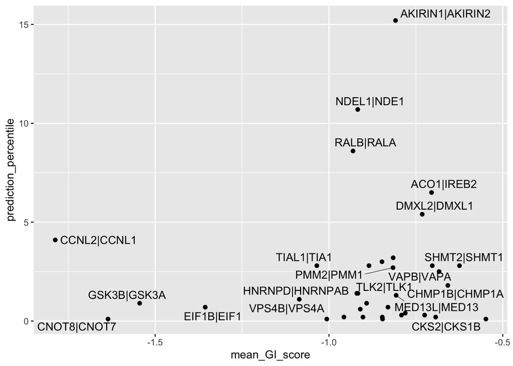

```r
                  # nudge_x = 500, force = 0.015, direction = "y", size = 2)

d.Parrish_DeKegel %>%
  filter(broad_SL_flag == "SL_in_both") %>%
  rowwise() %>%
  mutate(mean_GI_score = mean(c(PC9_gene_gene_GI_score, HeLa_gene_gene_GI_score))) %>%
  ggplot(aes(x = mean_GI_score, y = prediction_percentile)) +
  geom_point() +
  geom_text_repel(aes(label = paralog_pair), segment.size = 0.2)
```

```r
                  # nudge_x = 500, force = 0.015, direction = "y", size = 2)
```

```r
d.Parrish_DeKegel <- d.Parrish_DeKegel %>%
  mutate(top_5_percent_flag = ifelse(prediction_percentile < 5, TRUE, FALSE)) %>%
  mutate(comp_validated_flag = ifelse(broad_SL_flag != "SL_in_neither" &
                                        top_5_percent_flag == TRUE, TRUE, FALSE))

d.Parrish_DeKegel_high_conf <- d.Parrish_DeKegel %>%
  filter(broader_SL_flag == "SL_in_both" & comp_validated_flag == TRUE) %>%
  rowwise() %>%
  mutate(mean_GI_score = mean(c(PC9_gene_gene_GI_score, HeLa_gene_gene_GI_score)))
d.Parrish_DeKegel_high_conf
```

```
## # A tibble: 30 × 97
## # Rowwise:
##    paralog_pair      PC9_double_GI_s… PC9_gene_gene_G… PC9_GI_fdr HeLa_double_GI_…
##    <chr>                        <int>            <dbl>      <dbl>            <int>
##  1 SLC25A28|SLC25A37               23           -0.944   0.000489               49
##  2 AP2A1|AP2A2                     18           -0.978   0.00328                24
##  3 ARFGEF1|ARFGEF2                 28           -0.903   0.0142                 30
##  4 CCNL2|CCNL1                      1           -2.31    0.000165               10
##  5 CSTF2T|CSTF2                    32           -0.890   0.000441               17
##  6 TIAL1|TIA1                      20           -0.970   0.00154                18
##  7 GSK3B|GSK3A                      3           -1.43    0.00162                 4
##  8 HNRNPD|HNRNPAB                  11           -1.04    0.00171                36
##  9 COQ10B|COQ10A                    7           -1.12    0.00224                66
## 10 SEC24B|SEC24A                    6           -1.12    0.00246                54
## # … with 20 more rows, and 92 more variables: HeLa_gene_gene_GI_score <dbl>,
## #   HeLa_GI_fdr <dbl>, target1 <chr>, target2 <chr>, ensembl_pair_1 <chr>,
## #   ensembl_pair_2 <chr>, target1_ensembl_id <chr>, target1_hgnc_symbol <chr>,
## #   target1_chr <chr>, target1_start_pos <dbl>, target2_ensembl_id <chr>,
## #   target2_hgnc_symbol <chr>, target2_chr <chr>, target2_start_pos <dbl>,
## #   PC9_target1_TPM <dbl>, PC9_target2_TPM <dbl>, PC9_target1_entrez_id <int>,
## #   PC9_target2_entrez_id <int>, PC9_target1_essential <lgl>, …
```

```r
d.Parrish_DeKegel_medium_conf <- d.Parrish_DeKegel %>%
  filter(comp_validated_flag == TRUE)
```

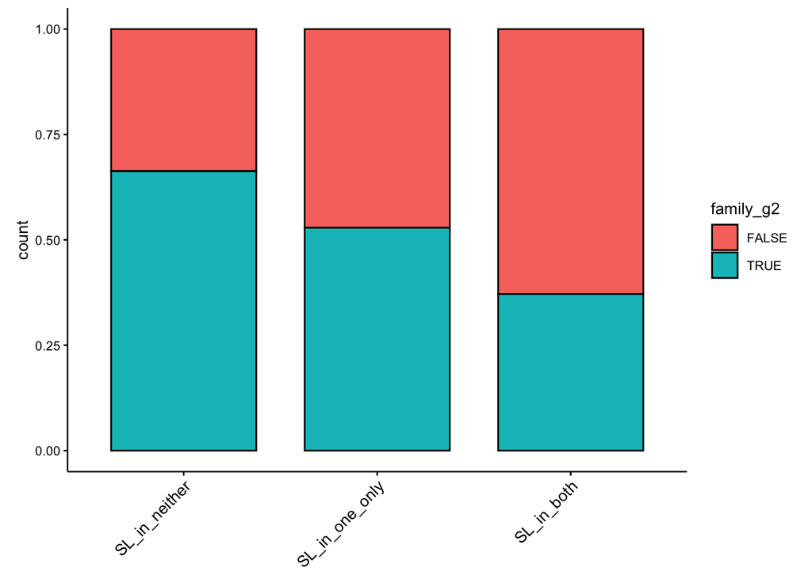

```r
d.Parrish_DeKegel %>%
  mutate(family_g2 = ifelse(family_size > 2, TRUE, FALSE)) %>%
  ggplot(aes(x = broader_SL_flag, fill = family_g2)) +
  geom_bar(position = "fill", width = 0.75, color = "black") +
  theme_classic(base_size = 10) +
  theme(aspect.ratio = 0.75,
        axis.text = element_text(color = "black"),
        axis.ticks = element_line(color = "black"),
        axis.text.x = element_text(angle = 45, hjust = 1, size = 10),
        axis.title.x = element_blank())
```

```r
# ggsave(file.path(out_dir, "pgPEN_SL_vs_family_size.pdf"),
#        height = 3, width = 4.5, useDingbats = FALSE)
```

This analysis showed that paralogs with >1 other family-member were less likely to be called synthetic lethal in our dataset, which makes sense given how we filtered the paralogs: we did not select only duplicate genes, Alice just filtered for those with ≥50% amino acid sequence identity with only one other paralog in the genome. Therefore, paralog pairs wtih other family-members with <50% sequence identity were included in our library.

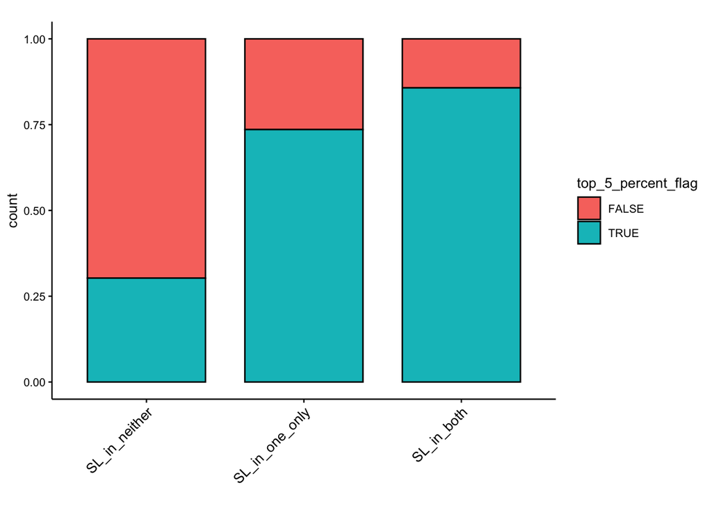

```r
ggplot(d.Parrish_DeKegel, aes(x = broader_SL_flag, fill = top_5_percent_flag)) +
  geom_bar(position = "fill", width = 0.75, color = "black") +
  theme_classic(base_size = 10) +
  theme(aspect.ratio = 0.75,
        axis.text = element_text(color = "black"),
        axis.ticks = element_line(color = "black"),
        axis.text.x = element_text(angle = 45, hjust = 1, size = 10),
        axis.title.x = element_blank())
```

```r
# ggsave(file.path(out_dir, "pgPEN_SL_vs_DeKegel_top5_percent.pdf"),
#        height = 3, width = 4.5, useDingbats = FALSE)
```

This analysis showed that our top hits from the SL screen are likely real, given that paralogs that are SL in ≥1 cell line are much more likely to be in the top 5th percentile of predicted broadly SL paralogs than those that were SL in neither cell line.

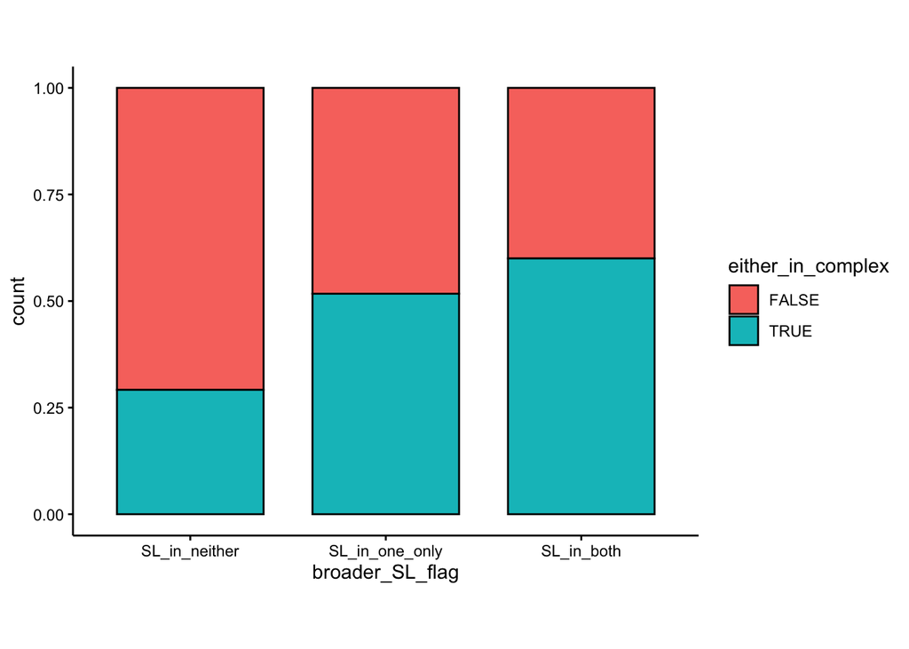

```r
ggplot(d.Parrish_DeKegel, aes(x = broader_SL_flag, fill = either_in_complex)) +
  geom_bar(position = "fill", width = 0.75, color = "black") +
  theme_classic() +
  theme(aspect.ratio = 0.75,
        axis.text = element_text(color = "black"),
        axis.ticks = element_line(color = "black"))
```

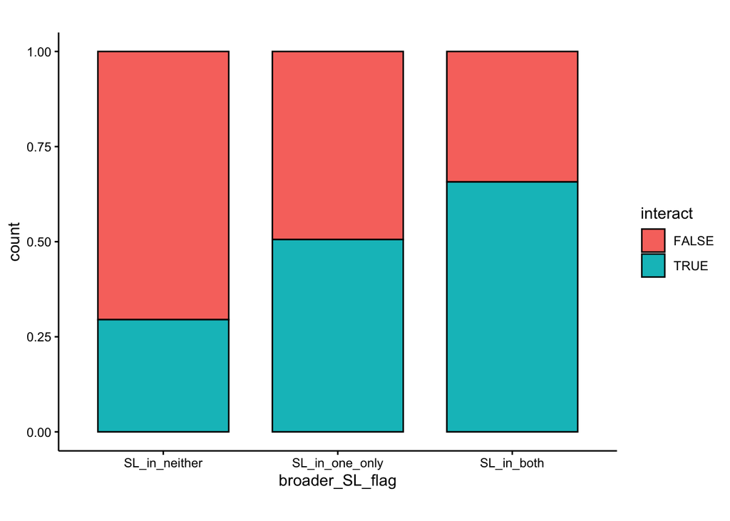

```r
ggplot(d.Parrish_DeKegel, aes(x = broader_SL_flag, fill = interact)) +
  geom_bar(position = "fill", width = 0.75, color = "black") +
  theme_classic() +
  theme(aspect.ratio = 0.75,
        axis.text = element_text(color = "black"),
        axis.ticks = element_line(color = "black"))
```

This analysis shows that paralogs that physically interact are more likely to be SL in ≥1 cell line compared to those that were SL in neither cell line.

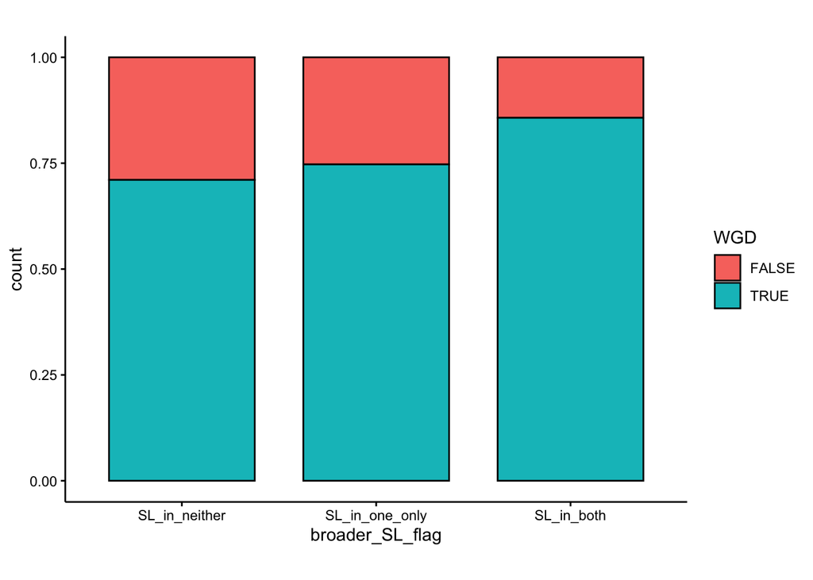

```r
ggplot(d.Parrish_DeKegel, aes(x = broader_SL_flag, fill = WGD)) +
  geom_bar(position = "fill", width = 0.75, color = "black") +
  theme_classic() +
  theme(aspect.ratio = 0.75,
        axis.text = element_text(color = "black"),
        axis.ticks = element_line(color = "black"))
```

This analysis shows that most of the paralogs in our library are whole genome duplicates (WGD). This was also shown in the De Kegel et al. 2021 preprint. This also shows that paralogs that were SL in both cell lines were enriched for WGD genes.

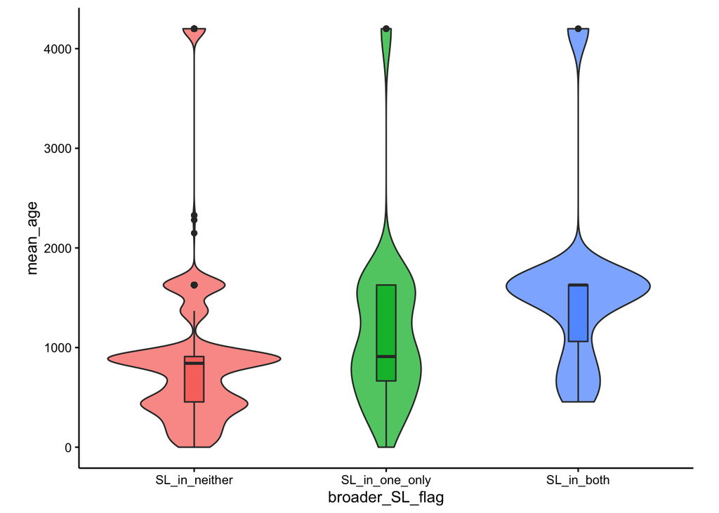

```r
ggplot(d.Parrish_DeKegel, aes(x = broader_SL_flag, y = mean_age, fill = broader_SL_flag)) +
  geom_violin(alpha = 0.75) +
  geom_boxplot(width = 0.1) +
  theme_classic() +
  theme(legend.position = "none",
        aspect.ratio = 0.75,
        axis.text = element_text(color = "black"),
        axis.ticks = element_line(color = "black"))
```

This analysis shows that SL paralogs were likely to be older. This makes sense in the context of WGD genes being more likely to be SL (see De Kegel preprint, yeast papers).

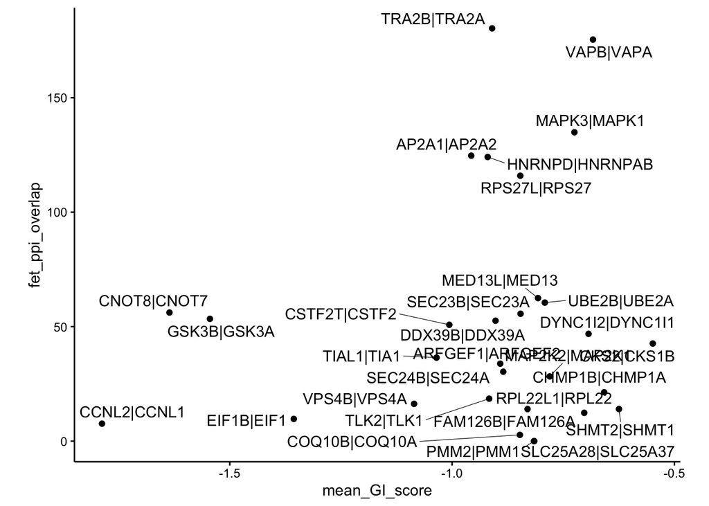

```r
ggplot(d.Parrish_DeKegel_high_conf, aes(x = mean_GI_score, y = fet_ppi_overlap)) +
  geom_point() +
  geom_text_repel(aes(label = paralog_pair), segment.size = 0.2) +
  theme_classic() +
  theme(legend.position = "none",
        aspect.ratio = 0.75,
        axis.text = element_text(color = "black"),
        axis.ticks = element_line(color = "black"))
```

This analysis compares the mean GI score across PC9 and HeLa cell lines to the PPI overlap among paralog pairs.